# A replicable temporal extension of protected area geodata applied to 123 sites in Madagascar

Authors

Affiliations

Florent Bédécarrats

Institut de Recherche pour le Développement (IRD), UMI-SOURCE

Seheno Ramanantsoa

Ministère de l’Environnement et du Développement Durable (MEDD)

Ollier D. Andrianambinina

Madagascar National Parks (MNP)

Published

October 21, 2026

Abstract

Georeferenced data on protected areas underpin much of the research studying the impacts of nature conservation on the environment and human wellbeing. Yet, existing databases typically record only the current state of each site. When boundaries or designations change, previous configurations are silently overwritten, preventing reliable temporal analyses and introducing bias in impact evaluations. We present a replicable temporal data model that extends the World Database on Protected Areas with time-bounded states documenting boundary modifications, status changes, temporary protections and internal zoning. The model is designed to be generalizable to any national context and extensible to the full diversity of protected area modifications. We apply the model to the 123 protected areas that constituted Madagascar’s national protected-area system through late 2025, reconstructing their histories over 2000–2025 from historical spatial datasets, successive national system datasets, legal texts from the national legislative database, and expert literature. All amendments are stored in a version-controlled YAML registry and consolidated through deterministic rules implemented in R. The resulting dataset is distributed in GeoPackage, RDS and Parquet formats, enabling spatio-temporal analyses of conservation dynamics. Although the sources and reconstruction process are country-specific, the amendment-based data model and consolidation engine can be applied to other national subsets of the WDPA.

*Corresponding author: Florent Bédécarrats (florent.bedecarrats@ird.fr)*

# Background and Summary

Geospatial data on protected areas occupy a central place in research assessing conservation outcomes on the environment and human wellbeing. Whether studies assess the effect of protection on deforestation, measure the economic returns of ecotourism, or monitor progress toward international conservation targets, they depend on accurate spatial boundaries and status information. The World Database on Protected Areas (WDPA), maintained by the UN Environment Programme World Conservation Monitoring Centre, serves this role as the most comprehensive global inventory, documenting over 270,000 sites across more than 240 countries and territories<sup>1</sup>. Over the past two decades, the WDPA has become the default spatial reference for conservation planning, effectiveness assessments, and reporting against targets such as Aichi Biodiversity Target 11 and, more recently, the Kunming-Montreal Global Biodiversity Framework goal to protect 30% of the planet by 2030<sup>2</sup>.

What remains largely unaddressed is the continuous evolution of ongoing protected areas. Between creation and the present, many sites undergo boundary modifications, status reclassifications (for instance from Strict Nature Reserve to National Park), governance changes, internal zoning, or temporary protection decrees. None of these transformations are preserved in the WDPA’s current-state model: each update silently replaces the previous configuration, making it impossible to reconstruct what a protected area looked like at any given date in the past from the current WDPA alone.

A further dimension that static snapshot databases fail to capture is the internal zoning of protected areas. In many national systems, multi-use protected area categories — typically corresponding to IUCN Categories III to VI — are internally subdivided into zones with distinct levels of permitted human activity. In Madagascar, the Protected Area Management Code (Code de Gestion des Aires Protégées, COAP; Law 2015-005) requires such sites to delineate a strictly protected core zone (noyau dur), where extractive uses are prohibited and biodiversity conservation takes legal precedence, alongside internal buffer zones where regulated resource use by surrounding communities may be permitted. The term “buffer zone” is used in the literature to refer both to areas surrounding core zones within protected areas and to areas surrounding the external boundary of protected areas<sup>6</sup>. To avoid ambiguity, we distinguish throughout this manuscript and dataset between “internal buffer zones” and “external buffer zones.” The temporal emergence of these zones is a critical feature of conservation trajectories: a protected area’s external boundary is typically established by an initial creation decree, while its core zone may be delimited and formalized either in that same decree or in the site’s management and development plan, together with the other zoning categories, at a later stage. Impact evaluations seek to estimate the causal effect of an intervention by comparing observed outcomes with an estimate of what would have occurred in its absence. For protected areas, this requires correctly identifying where and when protection applies. Errors in boundary geometry, protection dates, or legal status can therefore misclassify locations or periods as protected or unprotected and bias estimated effects. Internal zoning adds another dimension: evaluations relying solely on the external boundary may pool areas subject to different levels of restriction, potentially masking effects concentrated in more strictly protected zones.

This matters for researchers from all disciplines that study conservation (biology, ecology, economics, anthropology, etc.). For instance, if such an evaluation assumes that the current boundary has remained unchanged since a protected area was established, it may treat land incorporated only later as protected during earlier periods, thereby biasing the estimated effect of protection. It is also relevant for policymakers, as protected areas have become a major instrument of spatial planning, with global terrestrial coverage exceeding 17% in 2023<sup>7</sup>. It also matters for conservation practitioners and local stakeholders, because shared spatial references support more transparent and equitable management.

Madagascar offers a particularly instructive demonstration case. The island is one of the world’s foremost biodiversity hotspots, with forests sheltering over 80% of its biodiversity and endemism rates exceeding 80% across many taxonomic groups<sup>8</sup>. Its conservation history spans colonial-era strict nature reserves, post-independence national parks, and a rapid expansion following the 2003 Durban Vision, in which the government committed to tripling the protected surface to six million hectares<sup>8</sup>. This complex trajectory has been meticulously documented by Goodman et al.<sup>9</sup> in a three-volume monograph covering 98 terrestrial sites, while the national protected area system (Système des Aires Protégées de Madagascar, SAPM) has produced successive spatial datasets, and the national legislative database (Centre National d’information et de Documentation Législative et Juridique – CNLEGIS) contains the legal decisions underpinning each status change. Yet no single dataset has assembled these complementary sources into a unified temporal record.

The problem, however, is not specific to Madagascar. In most countries, the WDPA contains protected areas whose histories of boundary and status changes are lost. The historical evidence needed to reconstruct these trajectories is inherently country-specific: legal systems, spatial archives, protected-area identifiers and institutional records differ widely across jurisdictions. The transferable component of our approach is therefore not a standardized reconstruction procedure, but a common data model for encoding reconstructed changes as dated amendments to a WDPA baseline and consolidating them into temporal states.

This paper presents three contributions. First, a reusable temporal data model that represents protected-area histories as time-bounded amendments to a current WDPA baseline, including changes in external boundaries, legal status and internal zoning. Second, an application of this model to the 123 protected areas that constituted Madagascar’s national protected-area system through late 2025, reconstructed over 2000–2025 from country-specific spatial, legal and expert sources. Third, an open infrastructure consisting of a version-controlled YAML amendment registry and a deterministic consolidation engine, allowing curated histories to be audited, corrected and regenerated reproducibly.

# Methods

The dataset was constructed through a multi-step pipeline integrating four complementary data sources, cross-referencing them through spatial and textual matching, curating amendments through expert review, and consolidating them into temporal states using deterministic rules. Access to institutional datasets and validation processes was facilitated through close collaboration with national authorities, ensuring consistency with official records and operational practices.

The complete workflow, source documentation, curation notebooks, amendment registry and consolidation code are publicly available in the associated GitHub repository and its rendered Quarto documentation. We summarize the key steps below and illustrate the overall workflow in Figure 1.

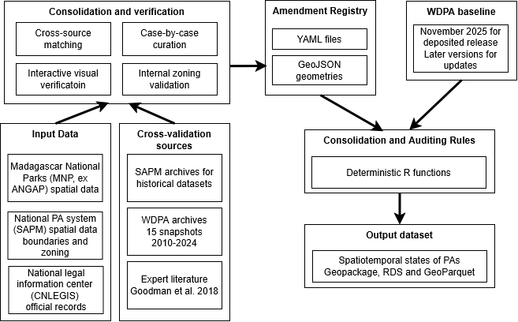

Figure 1: Workflow for reconstructing and consolidating protected-area histories. Input data provide geometries or dated attributes used to construct the amendment registry, whereas validation and contextual sources are used for comparison, interpretation and verification. The curated amendment registry is then applied to a WDPA baseline using the Consolidation and Auditing Rules. The deposited release uses the November 2025 WDPA baseline; later WDPA releases can be used to generate subsequent updates

The source-discovery and historical-reconstruction steps described below are specific to Madagascar and are not proposed as a standardized workflow for other countries. Generalizability instead lies in the downstream representation: once locally reconstructed changes are expressed through the amendment schema, the same consolidation model can transform any country-level WDPA baseline into a temporal dataset.

## Input data

Four categories of source material were assembled during the data reconstruction and validation process: spatial datasets produced or maintained by Malagasy institutions responsible for protected areas; current and historical versions of the World Database on Protected Areas; official legal records from the national legislative database and public gazette (Journal Officiel); and expert sources used to reconstruct or verify protected-area histories. These materials played different roles in the workflow: some were used only to identify or validate potential changes, whereas a more restricted set provides geometries or attribute amendments to the released dataset. Each geometry in the final files carries a “geometry_source_dataset_id” field, making it possible to identify the source actually used from sources that were consulted only during curation.

The current WDPA provides the baseline geometry and attributes to which documented historical amendments are applied. The consolidated release presented here uses the November 2025 WDPA for Madagascar, obtained from Protected Planet (https://www.protectedplanet.net). Historical WDPA snapshots were additionally examined during data preparation and validation. Versions from July 2017 onward were accessed through the Google Earth Engine WDPA archive; earlier snapshots for 2010–2016 were recovered from UNEP-WCMC’s public AWS archive. In one documented case, a historical geometry was reconstructed by separating polygons from the November 2025 WDPA geometry (labelled WDPA_2025_split in the metadata). WDPA-derived material is identified explicitly in the provenance metadata.

National spatial information comes from two institutional streams. First, “ANGAP_2002” is a historical spatial database of the Association Nationale pour la Gestion des Aires Protégées (ANGAP), which was renamed Madagascar National Parks (MNP) in 2008. The other MNP sources incorporated in the released dataset are “MNP_2010”, “MNP_Anka_RNI_pre2002” and “MNP_Mantadia_pre2002”; “MNP_2010_split” is a subdivision of “MNP_2010”, not an independent source. These geometries were produced, reconstructed or validated by co-author Ollier D. Andrianambinina in the context of his responsibilities at MNP and associated doctoral research. The original institutional source databases are not redistributed as such; requests concerning access to the underlying archives should be addressed to Madagascar National Parks, in particular its Information System and Innovation Department. MNP has provided written authorization for the use, adaptation, publication and redistribution of the ANGAP/MNP-derived geometries incorporated into this scientific dataset under CC BY 4.0, with appropriate attribution of their provenance.

A second national stream consists of official protected-area geographic information produced, compiled or coordinated within the SAPM and the Ministry of Environment and Sustainable Development (MEDD). The geometries from this stream that enter the released dataset are identified as SAPM_evol_2001-2011, SAPM_2010 and MEDD_subdivisions. The latter includes zoning information produced in the course of protected-area management, including by organizations operating under delegated management arrangements, and consolidated as part of the official geographic information associated with the protected-area system. Their institutional provenance and the legal framework governing the circulation and dissemination of protected-area geographic information were documented in a signed attestation by co-author Seheno Ramanantsoa, Head of the Protected Areas Governance Service within MEDD. The original historical source databases are not redistributed as such; requests concerning access to them should be addressed to the MEDD service responsible for protected-area governance and SAPM coordination.

Attribute amendments were derived from official legal records, principally decrees and ministerial or interministerial orders published through the Journal Officiel and made accessible through the Centre National de Légistique (CNLEGIS). These records were accessed through the CNLEGIS legislative database (https://www.cnlegis.gov.mg), using searches by legal instrument number, date, type and protected-area name or related keywords. Approximately 200 protected-area-related legal decisions were compiled and linked to WDPA identifiers using textual and spatial matching followed by manual verification. These legal records provide the authoritative basis for dates of creation, temporary protection, status changes, boundary modifications, and other dated amendments. WDPA attributes that are not explicitly amended are inherited from the baseline.

Additional sources, including the monograph by Goodman et al.<sup>9</sup> and the associated Vahatra dataset, were used for historical interpretation, cross-checking and validation. The associated Vahatra spatial data are publicly disseminated through the institutional portal (https://protectedareas.mg), which makes its content available under Creative Commons licences for reuse with attribution; these geometries are not redistributed in our released dataset.

Additional historical context was drawn from Waeber et al.<sup>8</sup>.

## Consolidation and verification

Records from all four sources were matched to WDPA identifiers through a combination of spatial matching (centroid distance and polygon overlap ratios) and string-distance matching on protected area names. This step resolved name variants and multi-polygon entities.

A Shiny web application was developed and deployed for domain expert review. The validation involved protected area managers, GIS specialists from MEDD and Madagascar National Parks, and researchers with long-term experience on Madagascar’s protected area system. The application overlays geometries from different sources and time periods on interactive Leaflet maps, with filtering by IUCN category, dataset of origin, and associated legal texts. This tool enabled visual comparison of boundaries reported by different sources for each protected area. The shiny application is embedded into the Chapter 5 of the companion website and a standalone instance is accessible at https://fbedecarrats-conservation-madascar-dashboard.share.connect.posit.cloud/.

Core-zone shapefiles produced by protected-area managers, including MEDD, MNP, MBG (Missouri Botanical Garden), GERP (Groupe d’Étude et de Recherche sur les Primates de Madagascar) and WWF (World Wildlife Fund), were assembled and compared with protected-area boundaries. These zoning data form part of the geographic information associated with the official management of protected areas under MEDD responsibility, including where MEDD delegates its management mandate to another organization. For the released dataset, the selected and harmonized zoning geometries are recorded under the source identifier “MEDD_subdivisions”. Of the 73 protected areas for which exploitable zoning information was available, 70 fall within the temporal scope of the dataset and were integrated as secondary zones; three sites created in 2026 were excluded.

For approximately 25 protected areas with complex histories, a detailed case-by-case review was conducted, cross-referencing legal decisions, historical boundaries from Goodman et al.<sup>9</sup>, and successive SAPM datasets. Figure 2 illustrates three such cases. Amendments were documented in Spatial Amendment Tables (SAT) for geometries and Feature Attribute Tables (FAT) for attributes, then exported to the canonical YAML format.

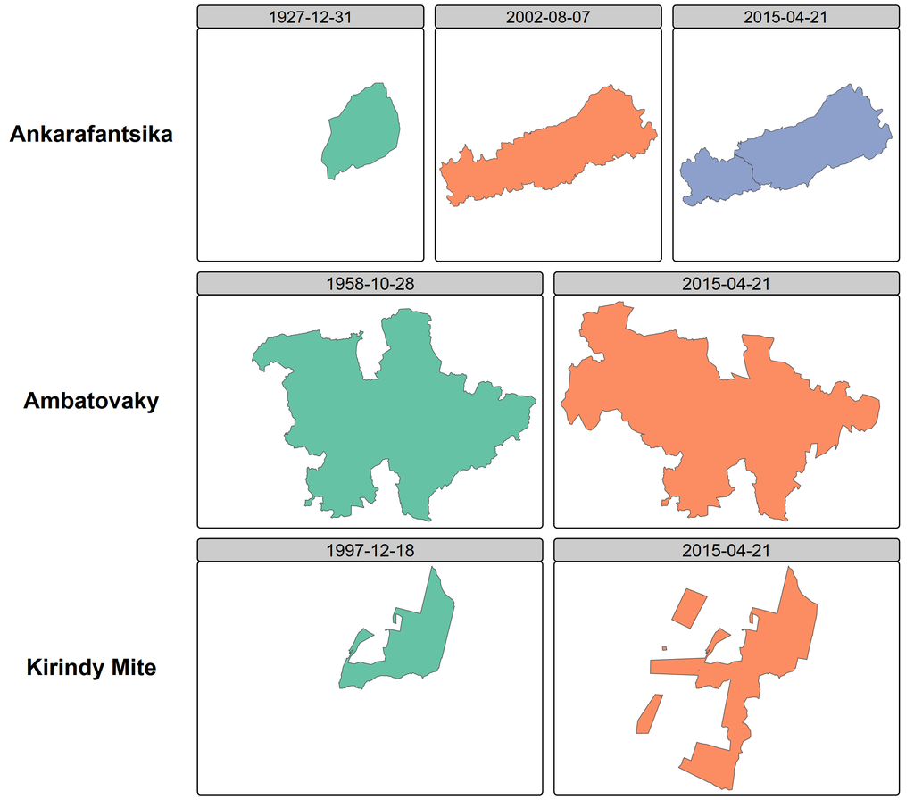

Figure 2: Temporal reconstruction for three protected areas

## YAML amendment registry

All corrections and temporal information are stored in a version-controlled registry of YAML files, with one file for each amendment. GeoJSON files are associated with amendments that introduce a new geometry. YAML was chosen because it is human-readable without specialized software, auditable in that each amendment includes the legal source, effective date, and amendment type, and Git-friendly in that text-based diffs enable collaborative editing with full change history tracking. Automated validation checks detect duplicate entries, temporal overlaps, and missing geometries.

The registry documents five types of amendments: boundary modifications, status changes, temporary protections, corrections to the WDPA baseline, and secondary zoning. In the Malagasy protected-area creation process, temporary protection refers to a legally binding provisional protection granted while a site proceeds toward definitive legal creation. During this provisional period, the site is subject in substance to the conservation restrictions associated with protected status; the distinction is primarily that the legal protection is granted for a limited period pending definitive designation. Temporary protection therefore does not indicate a protected area intended to be temporary or one that was subsequently degazetted.

## Consolidation and Auditing Rules

The final temporal states are generated by a deterministic consolidation engine implemented in R, referred to as the Consolidation and Auditing Rules (CAR). The engine reads the WDPA baseline and the YAML amendment registry, applies explicit precedence rules, and produces the output dataset. The process follows a delta-only model in which amendments override specific WDPA attributes or geometries for defined time intervals while all other attributes are inherited from the baseline. Three core functions implement the pipeline: “generate_timeline()” identifies temporal breakpoints from all amendments for a given WDPA identifier, “find_active_amendments()” determines which amendments are active at each time point, and “consolidate_pa_states()” merges baseline attributes with active amendments to produce each temporal state. Because the rules are coded explicitly and the inputs are versioned, the entire transformation is reproducible and auditable.

# Data Records

The dataset is publicly deposited in DataSuds under the persistent identifier https://doi.org/10.23708/VN2TWC, for Bedecarrats, Florent, Ramanantsoa, Seheno, Andrianambinina, Ollier D. , 2026, “Dynamic spatial conservation boundaries and internal zoning of Madagascar from 2000 to 2025”, DataSuds<sup>10</sup>. Version 2.0 contains three equivalent consolidated representations of the temporal dataset, “dynamic_wdpa.gpkg”, “dynamic_wdpa.rds”, and “dynamic_wdpa.parquet”. These three consolidated files contain the same information in distinct formats suited respectively to GIS software, R, and a broader range of data analysis solutions. The file “amendments.zip” contains a snapshot of the version-controlled YAML amendment registry and associated GeoJSON geometries.

The consolidated files are based on the November 2025 WDPA release and should therefore be regarded as a historical research snapshot rather than as the current official protected-area database. Users requiring the latest official protected and conserved area information should obtain it directly from Protected Planet. UNEP-WCMC has provided written authorization for redistribution of the Madagascar-specific WDPA-derived outputs included in this dataset. Commercial use remains subject to the WDPA Data License, which prohibits commercial use of WDPA materials and derivative works without prior written permission from UNEP-WCMC<sup>11</sup>.

Provenance is retained at row level. The field “amendment_source” records whether a row is inherited directly from the WDPA baseline, generated from a documented amendment, or reconstructed from amendment information where no current WDPA record exists. The field “geometry_source_dataset_id” records the spatial dataset from which the geometry itself originates. This enables users to trace each geometry in the released files back to the institutional or WDPA source actually used in the reconstruction.

Each row in the output dataset represents one zone in one temporal state. A protected area with boundary changes and internal zoning will have multiple rows across time periods. Table 1 describes the fields.

Table 1: Schema of the temporal states dataset.

| Field | Type | Description |
| --- | --- | --- |
| `state_id` | Character | Unique identifier for each temporal state |
| `WDPAID` | Character | WDPA identifier, enabling cross-reference with the global database |
| `valid_from` | Date | Start date of the temporal state’s validity period, inclusive |
| `valid_to` | Date | End date of the validity period, exclusive; `NA` indicates an open-ended state, normally the configuration valid at the reference date |
| `zone_type` | Character | Geometry role: `external_boundary` or `secondary_zoning` |
| `zone_name` | Character | Name or label of the secondary zone, where available |
| `geometry` | Geometry | Polygon or multipolygon in WGS84 (EPSG:4326) |
| `NAME` | Character | Protected area name |
| `DESIG` | Character | Designation type |
| `IUCN_CAT` | Character | IUCN management category |
| `STATUS` | Character | Designation status |
| `STATUS_YR` | Character | Year of current status |
| `GOV_TYPE` | Character | Governance type inherited from the WDPA baseline in this release |
| `MANG_AUTH` | Character | Management authority inherited from the WDPA baseline in this release |
| `amendment_source` | Character | `WDPA` for baseline-derived rows, a YAML amendment identifier for amended rows, or `amendments_only` where no current WDPA record exists |
| `geometry_source_dataset_id` | Character | Identifier of the spatial dataset from which the geometry originates |

The national temporal reconstruction targets the 123 protected areas that constituted Madagascar’s national protected area system until the end of 2025. The consolidated files additionally preserve the complete Madagascar WDPA baseline, including proposed and international-designation records, together with one historical dissolved protected-area record. The current release therefore contains 168 distinct WDPAIDs, represented by 367 temporal states and 437 zone-state rows. Secondary zoning is included for 70 protected-area identities.

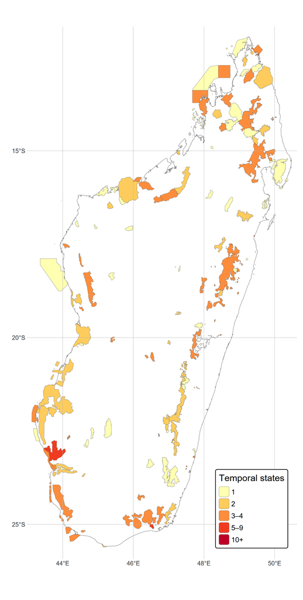

Figure 3: Map of the 123 protected areas that constituted Madagascar’s national protected-area system through the end of 2025, coloured according to the number of documented external-boundary temporal states. A value of 1 indicates that no boundary change is documented over the study period.

The temporal reconstruction changes the inferred evolution of protected-area extent. Figure 4 compares the annual national protected-area extent obtained by back-projecting the November 2025 WDPA through “STATUS_YR” with that obtained from the reconstructed historical states. The WDPA-based series shows a sharp increase in 2015, whereas the temporal reconstruction distributes this expansion across earlier years and accounts for historical boundary changes.

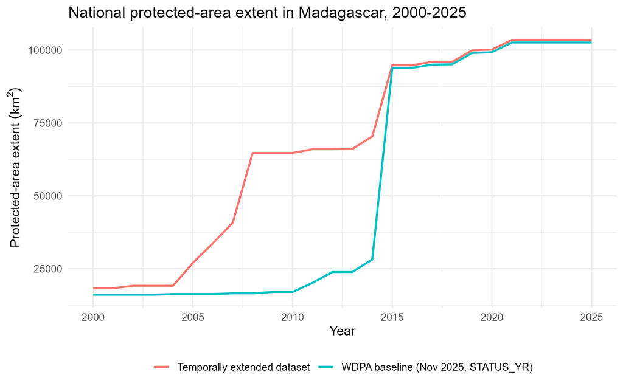

Figure 4: National protected-area extent in Madagascar according to the November 2025 WDPA baseline and the temporally extended dataset, 2000-2025. The WDPA series projects current national protected-area geometries backward from their recorded “STATUS_YR”; records with an unreported status year are excluded. The temporally extended series uses the external-boundary state in force at the end of each year.

By 2025 the two series nearly converge; the remaining difference of 878 km² corresponds to Tsimembo Manambolomaty, Mandrozo and Torotorofotsy, which have documented national legal histories in the reconstructed dataset but are represented only by international Ramsar records in the November 2025 WDPA.

The amendment schema and consolidation engine are independent of the particular sources used in Madagascar. They can therefore be applied to another country or region once locally reconstructed historical information has been expressed as dated amendments to the corresponding WDPA baseline.

# Technical Validation

Each amendment records its provenance and, where relevant, the legal instrument on which it is based. Legal amendments are linked to the corresponding decree or ministerial order and its effective date, while spatial amendments retain information on the source dataset from which their geometry was obtained.

Automated checks are applied during consolidation to detect duplicate temporal states, invalid or overlapping validity periods, empty geometries, missing geometry provenance and inconsistent protected-area identifiers. Additional checks ensure that national historical information is not inadvertently assigned to distinct international WDPA designations. The three distributed formats are also checked for consistency after generation.

Curated amendment geometries were checked during processing and spatial review. Baseline WDPA geometries are retained without silently modifying their topology, in order to preserve source fidelity.

Figure 5 summarizes the types and counts of amendments documented in the registry.

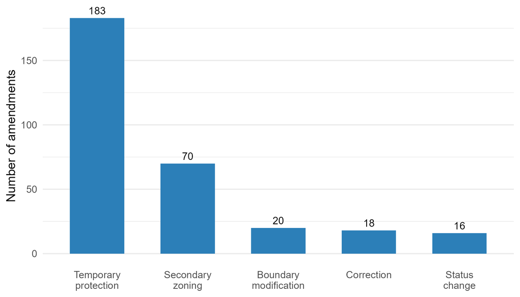

Figure 5: Types and counts of amendments documented in the YAML registry. Temporary protection denotes legally binding provisional protection pending definitive creation, rather than subsequent degazettement

# Usage Notes

The published dataset can be used directly without reproducing the data-preparation pipeline. The GeoPackage can be opened in standard GIS software including QGIS and ArcGIS and in R or Python through geospatial libraries. The Parquet representation is intended for efficient analytical workflows, while the RDS file preserves the R spatial object directly. The “WDPAID” field enables linkage with other WDPA-based datasets.

Temporal configurations can be selected using “valid_from” and “valid_to”. Validity intervals follow a start-inclusive and end-exclusive convention. An “NA” value in “valid_to” indicates that no later state is recorded and therefore normally identifies the configuration valid at the reference date. The “zone_type” field distinguishes external protected-area boundaries from secondary zoning geometries.

Researchers wishing to update the dataset beyond the November 2025 baseline can download a more recent WDPA release from Protected Planet and apply the published amendment registry using the Consolidation and Auditing Rules provided in the GitHub repository. This reconstruction route uses the curated YAML and GeoJSON amendment registry as input and does not require repeating the complete historical source-curation process.

Users must observe the reuse conditions associated with the underlying source data. In particular, commercial use of WDPA material or works derived from it requires prior written permission from UNEP-WCMC<sup>11</sup>. UNEP-WCMC has separately provided written authorization for public redistribution of the Madagascar-specific derived outputs included in this dataset for the non-commercial use case described here.

The YAML amendment registry is designed for collaborative extension. Researchers who identify additional legal texts, historical maps, or field-validated boundaries can propose corrections or new amendments through the associated GitHub repository, where changes remain auditable through version control. Proposed amendments are reviewed by the coauthors and incorporated into the curated registry by consensus. If consensus cannot be reached, final validation rests with Ollier D. Andrianambinina for protected areas managed by Madagascar National Parks (MNP), and with Seheno Ramanantsoa for other protected areas. The CAR engine then automates consolidation of accepted amendments; it does not perform their scientific or institutional validation. The interactive companion application allows users to explore individual protected areas and compare boundaries from different sources.

# Data Availability Statement

The complete dataset is publicly deposited in DataSuds under the persistent identifier https://doi.org/10.23708/VN2TWC<sup>10</sup>. Version 2.0 includes the consolidated files “dynamic_wdpa.gpkg”, “dynamic_wdpa.parquet”, and “dynamic_wdpa.rds”, together with the archived amendment registry “amendments.zip”, which contains a snapshot of the version-controlled YAML amendment registry and associated GeoJSON geometries. The three consolidated files contain the same substantive information in formats suited respectively to GIS software, R, and broader analytical workflows.

The consolidated files incorporate information derived from the November 2025 WDPA release. UNEP-WCMC has provided written authorization for redistribution of these Madagascar-specific derived outputs for this non-commercial use case. Commercial use of WDPA material or derivative works requires prior written permission from UNEP-WCMC<sup>11</sup>. The deposited files constitute a historical research snapshot; users requiring the latest official protected and conserved area data should obtain the current release directly from Protected Planet.

Source-specific reuse conditions apply to third-party material incorporated into the dataset. UNEP-WCMC has provided written authorization for redistribution of the Madagascar-specific WDPA-derived outputs for the non-commercial use case described here; commercial use of WDPA material or derivative works requires prior written permission from UNEP-WCMC. Madagascar National Parks has authorized the use, adaptation, publication and redistribution under CC BY 4.0 of the ANGAP/MNP-derived geometries incorporated into this dataset. For the SAPM/MEDD sources, including protected-area zoning information produced in the course of delegated management, their institutional provenance and the legal basis for public dissemination of protected-area geographic information have been documented in a signed attestation by co-author Seheno Ramanantsoa, Head of the Protected Areas Governance Service within MEDD. The attestation documents the statutory role of the ministry in the publication and dissemination of protected-area boundaries, zoning and associated geographic information; it does not constitute a general open licence for the underlying historical SAPM/MEDD databases.

Geometry-level provenance is recorded in “geometry_source_dataset_id”, while amendment-level provenance and corresponding legal sources are documented in the YAML registry. Source datasets that are not themselves redistributed can therefore be identified from the published metadata.

# Code Availability

All source code is available at https://github.com/BETSAKA/conservation-dynamic-madagascar under the MIT License. The repository contains the Quarto documentation, interactive verification application, amendment registry, and CAR consolidation engine. Data files contained in or linked from the repository remain subject to the source-specific reuse conditions described in the Data Availability Statement.

# Acknowledgements

The project is coordinated by IRD/UMI-SOURCE and the Université d’Antananarivo/CERED. We thank the Vahatra Association for the foundational monograph on Madagascar’s protected areas, the CNLEGIS team for maintaining the national legislative database, and the organizations (MEDD, MNP, MBG, GERP, WWF) that shared core zone spatial data.

# Funding

This work was supported by KfW (grant number BMZ 2018-68-538 / KfW 108778), Agence Française de Développement (grant number PAIRES-CZZ2557), and Agence Nationale de la Recherche (grant number ANR-22-CPJ1-0052-01).

# Author Contributions

Following the CRediT (Contributor Roles Taxonomy) framework: F.B.: Conceptualization, Methodology, Software, Formal analysis, Data curation, Writing – original draft, Visualization, Project administration. S.R.: Investigation, Data curation, Validation, Resources, Writing – review & editing. O.D.A.: Investigation, Data curation, Validation, Resources, Writing – review & editing.

# Competing Interests

S.R. is a civil servant in charge of protected area governance at the Ministère de l’Environnement et du Développement Durable of Madagascar. O.D.A. heads the data information system and innovation unit at Madagascar National Parks. Producing and maintaining protected area information is part of their professional responsibilities. The authors have no financial conflicts of interest to declare.

# References

1.

Bingham, H. C. *et al.* Sixty years of tracking conservation progress using the World Database on Protected Areas. *Nature Ecology & Evolution* **3**, 737–743 (2019).

2.

Maxwell, S. L. *et al.* Area-based conservation in the twenty-first century. *Nature* **586**, 217–227 (2020).

3.

Bingham, H. C. *et al.* *User Manual for the World Database on Protected Areas and World Database on Other Effective Area- Based Conservation Measures: 1.6*. (UNEP-WCMC, Cambridge, UK, 2019).

4.

Symes, W. S., Rao, M., Mascia, M. B. & Carrasco, L. R. Why do we lose protected areas? Factors influencing protected area downgrading, downsizing and degazettement in the tropics and subtropics. *Global Change Biology* **22**, 656–665 (2016).

5.

Lewis, E. *et al.* Dynamics in the global protected-area estate since 2004. *Conservation Biology* **33**, 570–579 (2019).

6.

Ebregt, A. & De Greve, P. Buffer Zones and their Management. Policy and Best Practices for terrestrial ecosystems in developing countries. Theme Studies Series 5, Forest, Forestry and Biological Support Group. National Reference Centre for Nature Management. *International Agricultural Centre, The Netherlands, 64pp* (2000).

7.

UNEP-WCMC and IUCN. *Protected Planet Report 2024*. (UNEP-WCMC; IUCN, Cambridge, United Kingdom; Gland, Switzerland, 2024).

8.

Waeber, P. O., Rafanoharana, S., Rasamuel, H. A. & Wilmé, L. Parks and reserves in Madagascar: Managing biodiversity for a sustainable future. *Protected Areas, National Parks and Sustainable Future. AN Bakar and MN Suratman (eds.)* 89–108 (2020) doi:http://dx.doi.org/10.5772/intechopen.85348.

9.

Goodman, S. M. *et al.* *Les Aires Protégées Terrestres de Madagascar: Leur Histoire, Description Et Biote.* (Association Vahatra, 2018).

10.

Bédécarrats, F., Ramanantsoa, S. & Andrianambinina, O. D. Dynamic spatial conservation boundaries and internal zoning of madagascar from 2000 to 2025. DataSuds https://doi.org/10.23708/VN2TWC (2026).

11.

UNEP-WCMC. [WDPA data license](https://www.unep-wcmc.org/en/wdpa-data-license). (2026).